# Operação Zelotes

Renata Hirota

1/14/2020

# Cinco anos de Operação Zelotes: as mudanças no Carf após investigações de corrupção

A ponto de cumprir cinco anos desde a deflagração de sua primeira fase em março de 2015, a Operação Zelotes investigou, desde então, ao menos 70 empresas pelo esquema de corrupção no Carf (Conselho de Administração de Recursos Federais). O órgão do Ministério da Fazenda, criado em 2008, é responsável por julgar recursos administrativos de autuações contra empresas e pessoas físicas. Segundo a Polícia Federal, conselheiros do Carf manipulavam processos a favor de determinadas empresas em troca de pagamentos.

Considerando o período anterior e posterior ao início da operação, algumas diferenças nos processos do órgão emergem. Analisando os processos de 2010 a 2019, a primeira grande diferença é no volume de decisões publicadas, que durante os primeiros anos da operação sofreu uma queda expressiva. Os resultados das decisões também possuem padrões diferentes dependendo de fatores como o tipo de voto e o tipo de recurso.

## Volume de decisões

Em 2015 e 2016, logo após o início da Operação Zelotes, o Carf publicou menos decisõesem comparação aos outros anos analisados. Vale lembrar também que, além das perturbações causadas pelas investigações, em junho de 2015 o Carf teve seu novo regimento interno aprovado – cujo texto sofreu alterações ao longo de 2016, 2017 e 2018.

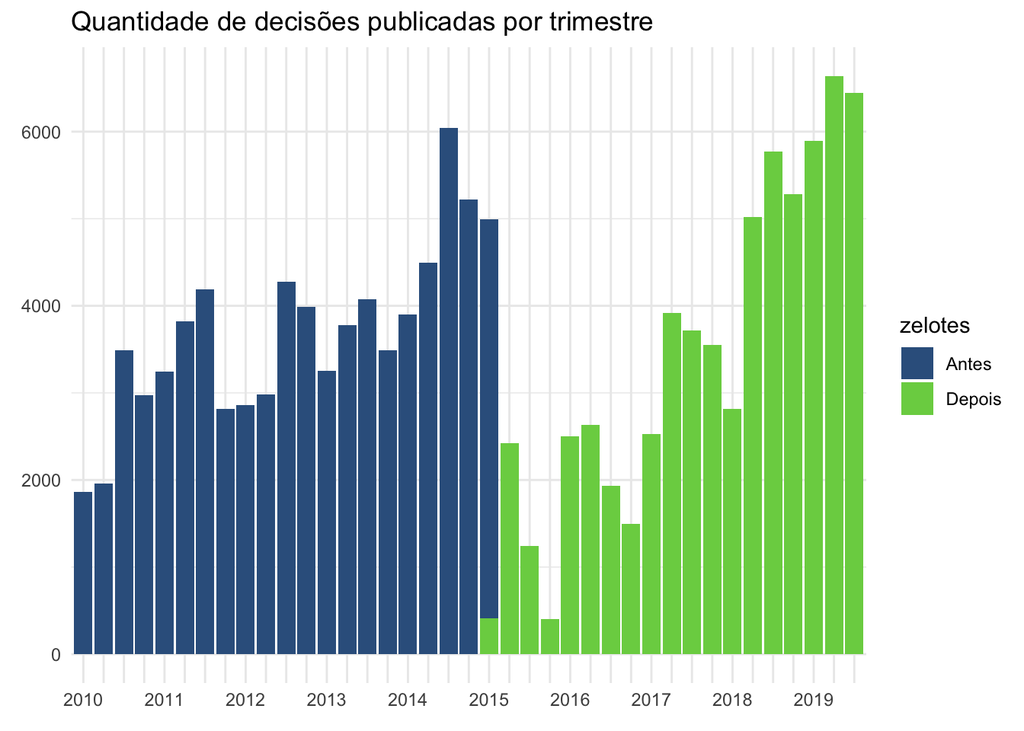

Quanto ao resultado das decisões, em 2015 e 2016 o volume de decisões favoráveis ou parcialmente favoráveis superou o total de decisões desfavoráveis, voltando a um patamar similar ao anterior à operação a partir de 2017. Outras mudanças encontradas nas distribuições dos resultados para certas categorias de tipos de voto e tipos de recurso reforçam tal comportamento.

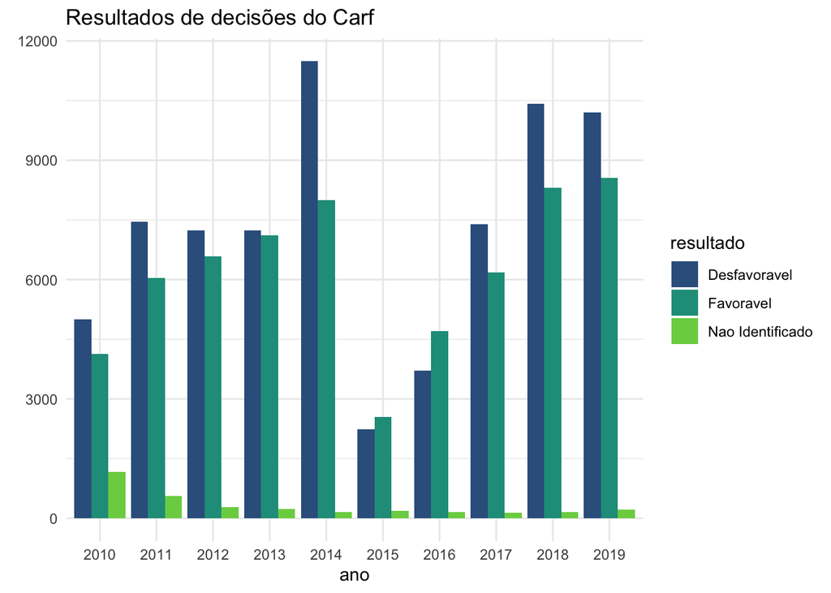

## Tipo de voto

Apesar de não representar um volume muito grande (cerca de 8% de todas as decisões), o padrão dos resultados de decisões por voto de qualidade teve uma mudança expressiva a partir do início da Operação Zelotes.

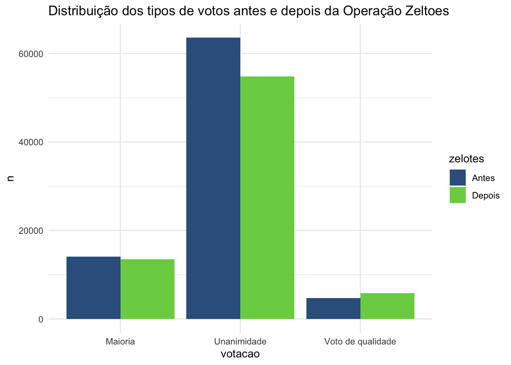

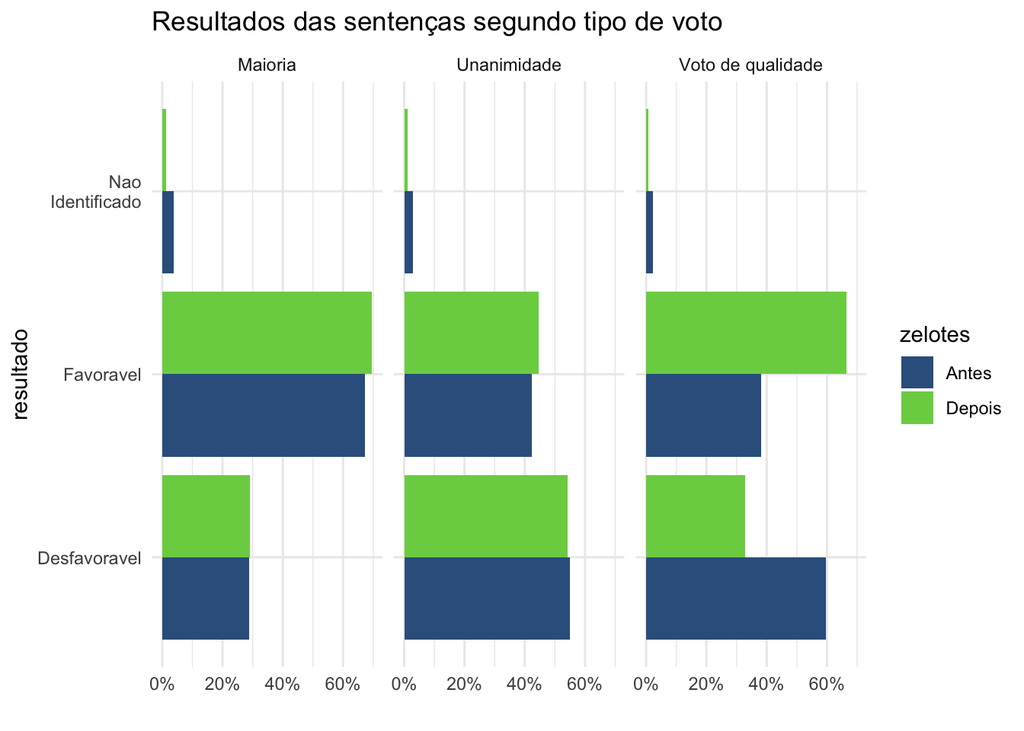

A quantidade de resultados favoráveis ao contribuinte superou o total de resultados desfavoráveis a partir de 2016, chegando a ser o dobro em alguns anos. É interessante notar que esse novo padrão se manteve ao longo do tempo, não se contendo apenas ao período inicial da operação.

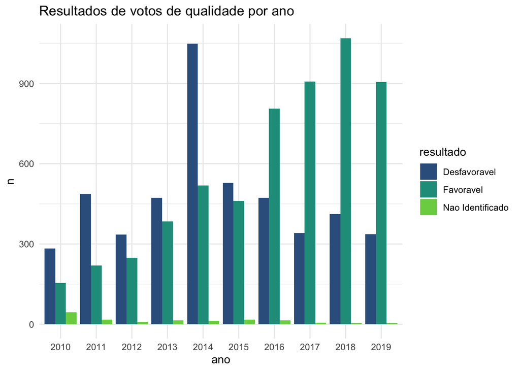

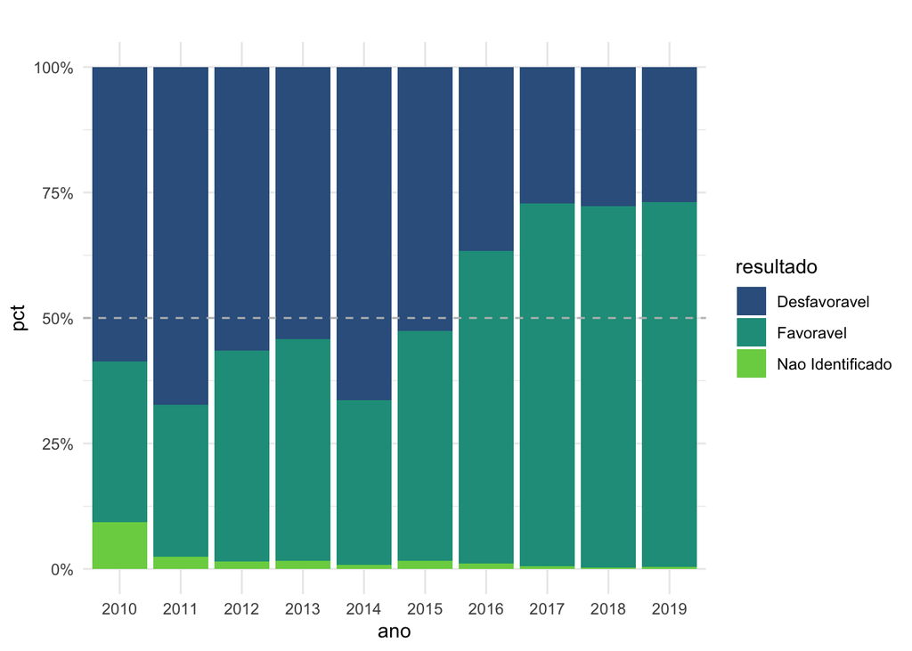

## Tipo de recurso

Diferentemente do comportamento geral, as mudanças nos resultados por tipo de recurso ocorreram somente a partir de 2017, depois das fases iniciais da Operação Zelotes já deflagradas. Após mais de dois anos desde o início da operação, recursos especiais do contribuinte passaram a terem decisões mais favoráveis ao contribuinte.

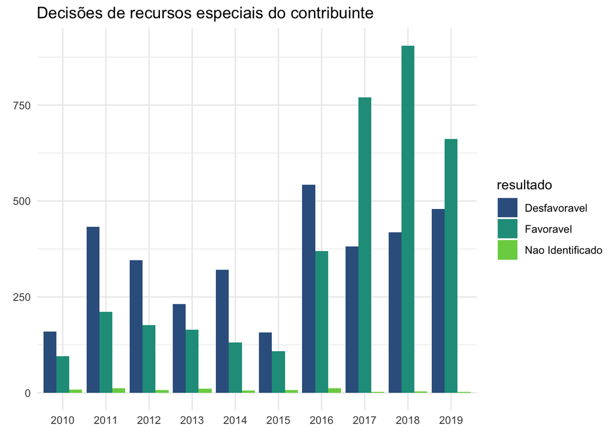

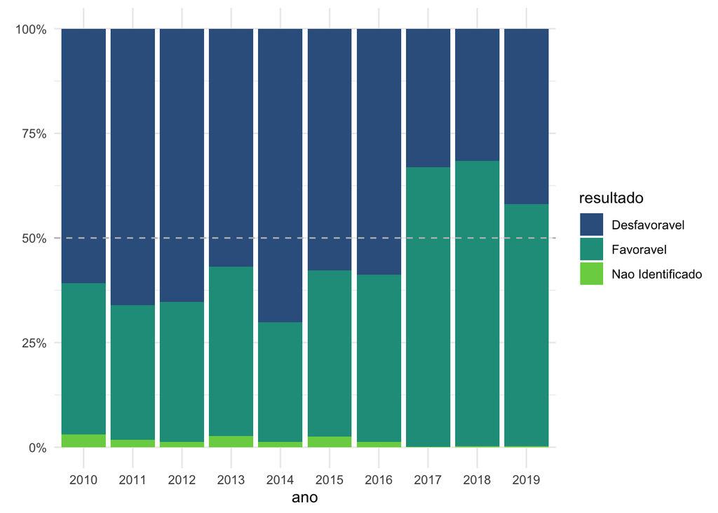

## Segmento

Considerando os segmentos mais comuns das partes envolvidas nos processos do Coaf, nota-se que pessoas físicas têm um padrão diferente do restante – em geral, recebem resultados mais favoráveis que desfavoráveis. Para o restante dos segmentos, no ano anterior à Operação Zelotes, o total de decisões desfavoráveis aumenta consideravelmente em relação às decisões favoráveis.

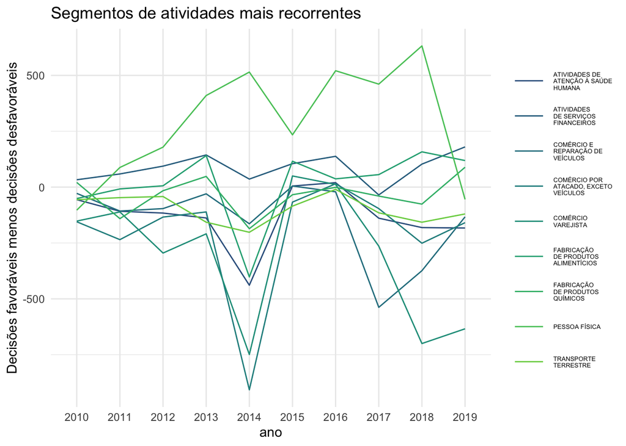

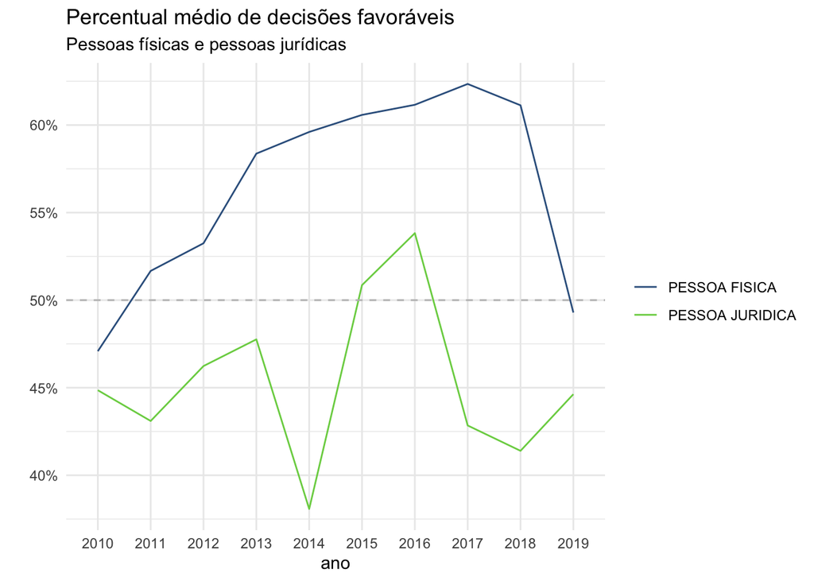

## UF

Por fim, analisando os estados em que as decisões em primeira instância foram tomadas, observamos que a proporção de decisões favoráveis ao contribuinte tende a ser maior em processos provenientes de estados da região norte, principalmente antes da Operação Zelotes. Após o início da operação, há uma mudança nesse padrão, e, de forma geral a proporção de decisões favoráveis aumenta, como já observado no panorama geral.

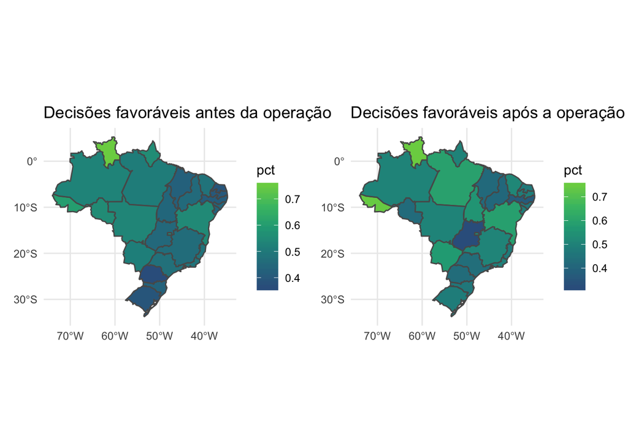

## Conclusões

Apesar de ser uma análise meramente descritiva, é interessante notar que existe uma mudança de padrão nas decisões do Carf antes e depois da Operação Zelotes. A inflexão no caso de deciões a partir de votos de qualidade, por exemplo, ocorre justamente a partir da época do início da operação da Polícia Federal. Outra frente não abordada neste post, mas que poderia render conclusões pertinentes, seria analisar as mudanças de padrões em decisões de acordo com os tributos e seções, câmaras e turmas, já que, além de serem intimamente relacionados, mudanças estruturais no Carf também podem ter afetado as decisões.

## Sobre a base de dados

A base de dados do Carf foi obtida diretamente do [site do Carf](https://carf.fazenda.gov.br/sincon/public/pages/ConsultarJurisprudencia/consultarJurisprudenciaCarf.jsf), através da implementação de rotinas automatizadas de download e limpeza dos gráficos. Os processos obtidos também foram consultados na [plataforma Comprot](https://comprot.fazenda.gov.br/comprotegov/site/index.html), que contém informações da primeira instân cia dos processos administrativos tributários federais. A base também utilizou informações dos dados abertos de CNPJ, obtidos através do portal [Brasil.IO](https://brasil.io). A base precisou passar por uma série de algoritmos de arrumação de dados, a partir da aplicação de técnicas de mineração de texto das ementas, decisões e nomes de relatores. A base final contém 141.900 acórdãos publicados entre 01/01/2010 e 30/09/2019.